# Simulating and Estimating Sequence Data

Josef Uyeda

2026-09-16

## Installing IQ-TREE

In this lab, we will simulate sequence evolution along a known phylogeny and then try to re-estimate that phylogeny from the simulated data. We will also estimate a small phylogeny from empirical data.

Before we start, install IQ-TREE:

- [Download IQ-TREE](https://iqtree.github.io/)
- [Installation instructions and basic usage](https://iqtree.github.io/doc/Quickstart#installation)

IQ-TREE is a command-line program. After you download and extract it, you cannot simply double-click the program; you must run it from a terminal.

It is worth installing IQ-TREE and becoming comfortable with command-line programs. However, if you cannot get the local installation to work, or do not want to install it for now, use the [IQ-TREE web server](https://www.hiv.lanl.gov/content/sequence/IQTREE/iqtree.html).

## Phylogeny simulation and estimation

We will need two R packages. If you successfully installed `phytools`, you already have both of them, so we only need to load them.

```r
# install.packages("phangorn")
library(ape)
library(phangorn)
```

Download the phylogeny lab directory from the course GitHub repository or the Canvas site. Make sure you are working in the phylogeny lab directory and that the file `bears.tre` is in your working directory.

```r
getwd()
```

```
## [1] "/home/juyeda/repos/macrophy_course/projects/phylogenylab"
```

```r
list.files()
```

```
##  [1] "66f20e5ec8df1"            "66f20e5ec8df1.zip"
##  [3] "bears_irbp.nex"           "bears.tre"
##  [5] "iqtree3"                  "iqtree3_arm"
##  [7] "iqtree3_intel"            "PhylogenyLab_revised.Rmd"
##  [9] "PhylogenyLab.html"        "PhylogenyLab.Rmd"
```

Now read the bear phylogeny. We will treat this as our “true tree.”

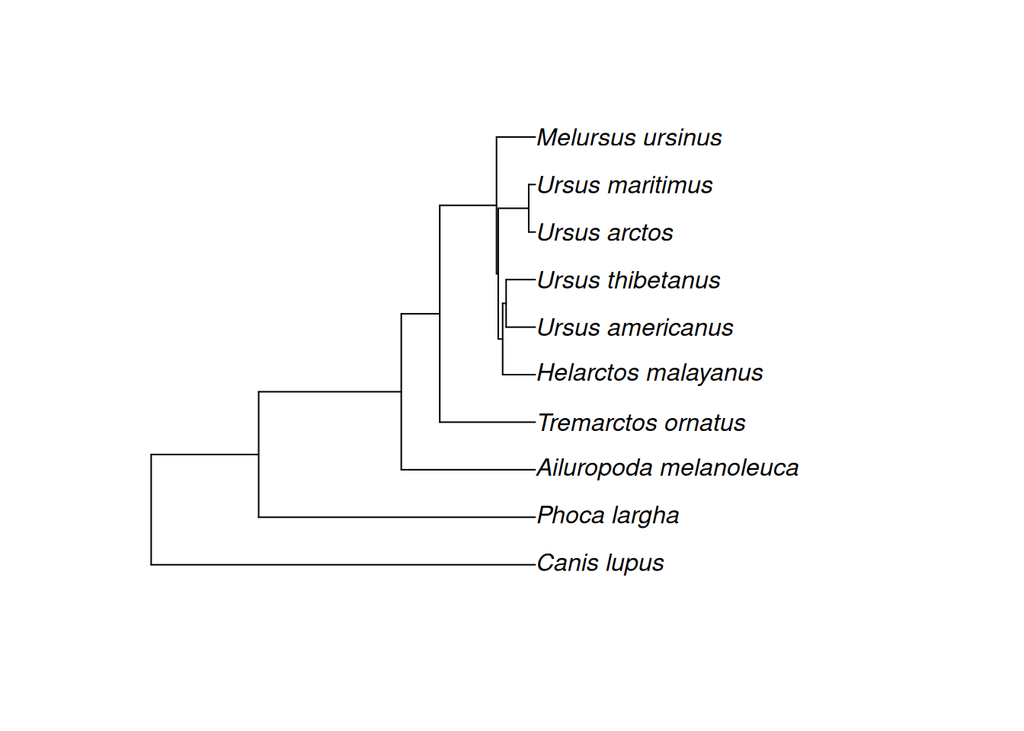

```r
tree <- read.nexus("./bears.tre")
plot(tree)
```

The tree is stored as a list-like object with four main components:

- `$edge`: the topology of the tree, represented as a two-column matrix of ancestral and descendant nodes
- `$edge.length`: the branch lengths corresponding to the rows of the edge matrix
- `$Nnode`: the number of internal nodes
- `$tip.label`: the labels of the tips (nodes 1 through 10 in this case)

Inspect `tree$edge.length`. What units do you think the branch lengths use?

```r
tree
```

```
##
## Phylogenetic tree with 10 tips and 9 internal nodes.
##
## Tip labels:
##   Canis_lupus, Phoca_largha, Ailuropoda_melanoleuca, Tremarctos_ornatus, Helarctos_malayanus, Ursus_americanus, ...
##
## Rooted; includes branch length(s).
```

```r
str(tree)
```

```
## List of 4
##  $ edge       : int [1:18, 1:2] 11 11 12 12 13 13 14 14 15 16 ...
##  $ edge.length: num [1:18] 55.1 15.4 39.7 20.4 19.2 ...
##  $ Nnode      : int 9
##  $ tip.label  : chr [1:10] "Canis_lupus" "Phoca_largha" "Ailuropoda_melanoleuca" "Tremarctos_ornatus" ...
##  - attr(*, "class")= chr "phylo"
##  - attr(*, "order")= chr "cladewise"
```

```r
tree$edge.length
```

```
##  [1] 55.0784968 15.4159828 39.6625139 20.4495703 19.2129436  5.5202105
##  [7] 13.6927330  8.1390471  0.2452951  0.6354615  4.6729294  0.4972256
## [13]  4.1757037  4.1757037  4.3713959  0.9369949  0.9369949  5.5536860
```

```r
tree_sl <- tree
tree_sl$edge.length <- tree$edge.length/200 + 0.01
```

Now build a rate matrix, $Q$. How many free parameters does this model have? What does it assume about the evolutionary process?

```r
Q <- matrix(0, nrow=4, ncol=4) # Make an empty matrix.
rownames(Q) <- colnames(Q) <- c("a", "c", "g", "t") # Label rows and columns.
Q[lower.tri(Q)] <- Q[upper.tri(Q)] <- c(0.2, 0.6, 0.2, 0.2, 0.6, 0.2) # Substitution rates.
diag(Q) <- -1*rowSums(Q) # Set each diagonal to the negative row sum.
Q
```

```
##      a    c    g    t
## a -1.0  0.2  0.6  0.2
## c  0.2 -1.0  0.2  0.6
## g  0.6  0.2 -1.0  0.2
## t  0.2  0.6  0.2 -1.0
```

```r
pi <- c("a"=0.25, "c"=0.25, "g"=0.25, "t"=0.25)
pi
```

```
##    a    c    g    t
## 0.25 0.25 0.25 0.25
```

The off-diagonal elements of $Q$ describe instantaneous substitution rates. The diagonal elements are negative because they describe the total rate of leaving each state. The vector `pi` gives the equilibrium base frequencies.

There are many programs for simulating sequences, including stand-alone tools with additional features such as AliSim. The `phangorn` package provides a convenient function that works from within R.

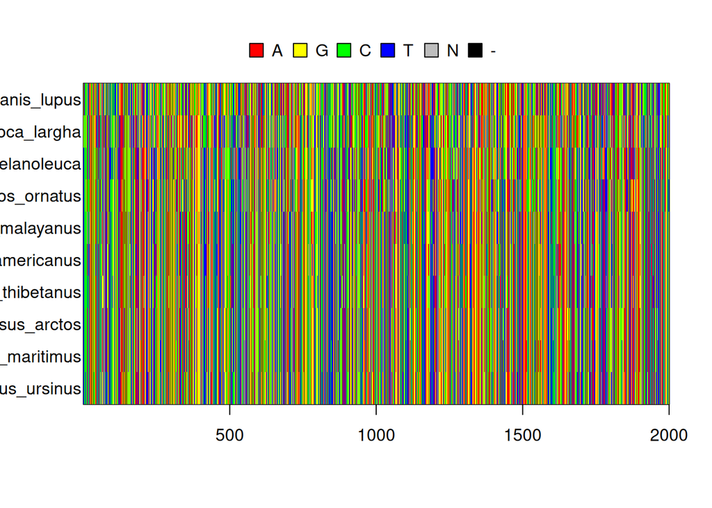

```r
data <- phangorn::simSeq(tree_sl, l=2000, Q=Q, bf=pi, type="DNA")
image(data) # A rough visualization of the DNA sequence alignment.
```

```r
# More polished options exist in packages such as ggmsa, but are not needed here.
```

Before continuing, inspect the alignment visualization. Which sites appear constant, and which appear variable? What information in the alignment could help us recover the tree?

We can create a distance matrix and use it to build a neighbor-joining tree.

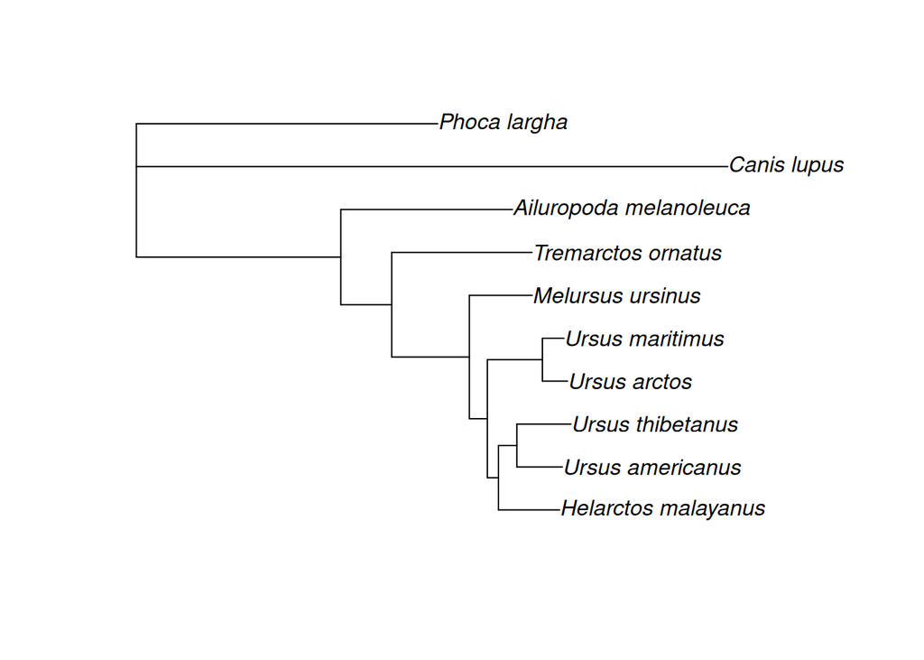

```r
D <- dist.dna(as.DNAbin(data))
njtree <- nj(D)
njtree <- root(njtree, "Canis_lupus")
plot(njtree)
```

Compare the neighbor-joining tree with the true tree.

Next, export the simulated alignment so that we can estimate a maximum-likelihood phylogeny with IQ-TREE.

```r
write.phyDat(data, file="./sim1_bears.fasta", format="fasta")
```

Estimate the phylogeny using either the IQ-TREE web server or the downloaded version of IQ-TREE. We want to use model selection and conduct 1,000 ultrafast bootstrap replicates.

I will demonstrate the command-line program in class. For long-term use, you should move the IQ-TREE executable into your system’s `PATH` so that you can run it from any directory. Package managers such as Conda, Homebrew, and `apt` usually do this automatically.

If you downloaded and extracted IQ-TREE manually, the executable will not automatically be added to your `PATH`. For now, the easiest way to minimize the amount of typing and searching is to copy the entire contents of IQ-TREE’s `bin` directory into your `phylogenyLab` folder.

Run the following line, replacing `iqtree3` with the name of your IQ-TREE executable. The `-s` option specifies the alignment file, and `-m MFP` requests model selection followed by phylogeny estimation.

```bash
./iqtree3 -s ./sim1_bears.fasta -m MFP -bb 1000 -redo
```

```
## IQ-TREE version 3.1.4 for Linux x86 64-bit built Sep 10 2026
## Developed by Bui Quang Minh, Thomas Wong, Nhan Ly-Trong, Huaiyan Ren
## Contributed by Lam-Tung Nguyen, Dominik Schrempf, Chris Bielow,
## Olga Chernomor, Michael Woodhams, Diep Thi Hoang, Heiko Schmidt
##
## Host:    UYEDA-D00R7FQ (AVX2, FMA3, 30 GB RAM)
## Command: /home/juyeda/repos/macrophy_course/projects/phylogenylab/iqtree3_intel -s ./sim1_bears.fasta -m MFP -bb 1000 -redo
## Seed:    28662 (Using SPRNG - Scalable Parallel Random Number Generator)
## libarcher.so: cannot open shared object file: No such file or directory
## Time:    Wed Sep 16 23:25:45 2026
## Kernel:  AVX+FMA - 1 threads (8 CPU cores detected)
##
## HINT: Use -nt option to specify number of threads because your CPU has 8 cores!
## HINT: -nt AUTO will automatically determine the best number of threads to use.
##
## Reading alignment file ./sim1_bears.fasta ... Fasta format detected
## Reading fasta file: done in 0.000133038 secs using 39.84% CPU
## Alignment most likely contains DNA/RNA sequences
## Constructing alignment: done in 0.000844955 secs using 97.28% CPU
## Alignment has 10 sequences with 2000 columns, 573 distinct patterns
## 557 parsimony-informative, 848 singleton sites, 595 constant sites
##                         Gap/Ambiguity  Composition  p-value
## Analyzing sequences: done in 9.77516e-06 secs using 102.3% CPU
##    1  Canis_lupus               0.00%    passed     96.29%
##    2  Phoca_largha              0.00%    passed     72.29%
##    3  Ailuropoda_melanoleuca    0.00%    passed     87.24%
##    4  Tremarctos_ornatus        0.00%    passed     91.03%
##    5  Helarctos_malayanus       0.00%    passed     90.71%
##    6  Ursus_americanus          0.00%    passed     86.83%
##    7  Ursus_thibetanus          0.00%    passed     99.98%
##    8  Ursus_arctos              0.00%    passed     93.54%
##    9  Ursus_maritimus           0.00%    passed     88.45%
##   10  Melursus_ursinus          0.00%    passed     94.41%
## ****  TOTAL                     0.00%  0 sequences failed composition chi2 test (p-value<5%; df=3)
## Checking for duplicate sequences: done in 2.00272e-05 secs using 99.86% CPU
##
##
## Create initial parsimony tree by phylogenetic likelihood library (PLL)... 0.000 seconds
## Perform fast likelihood tree search using GTR+I+G model...
## Estimate model parameters (epsilon = 5.000)
```

[output cut: 97 more lines]

```
## Consensus tree written to ./sim1_bears.fasta.contree
## Reading input trees file ./sim1_bears.fasta.contree
## Log-likelihood of consensus tree: -11329.197
##
## Analysis results written to:
##   IQ-TREE report:                ./sim1_bears.fasta.iqtree
##   Maximum-likelihood tree:       ./sim1_bears.fasta.treefile
##   Likelihood distances:          ./sim1_bears.fasta.mldist
##
## Ultrafast bootstrap approximation results written to:
##   Split support values:          ./sim1_bears.fasta.splits.nex
##   Consensus tree:                ./sim1_bears.fasta.contree
##   Screen log file:               ./sim1_bears.fasta.log
##
## Date and Time: Wed Sep 16 23:25:45 2026
```

How closely does the maximum-likelihood tree match the true tree? When they differ, is the disagreement associated with low bootstrap support? Did it estimate parameters of the evolutionary model accurately? Did it pick the right model? Under which information criteria?

The following code extracts fitted parameters from the IQ-TREE report. It is not elegant, and it depends on the formatting of that report. You could instead transcribe the values into an R object, but extracting them keeps the analysis reproducible.

```r
extractSubModelLog <- function(file){
  params <- list()
  log <- readLines(file)
  Qstart <- (grep("Rate matrix Q:", log)+2)
  Qend <- Qstart +3
  Qest <- do.call(rbind, lapply(strsplit(log[Qstart:Qend], split='[ \t]+'), function(x) x[3:6]))
  class(Qest) <- "numeric"
  diag(Qest) <- 0
  diag(Qest) <- -1*rowSums(Qest)
  colnames(Qest) <- rownames(Qest) <- c("a", "c", "g" ,"t")
  params$Q <- Qest

  piStart <- grep("State frequencies", log)+2; piEnd <- piStart+3
  stateFreq <- as.numeric(sapply(strsplit(log[piStart:piEnd], "= "), function(x) x[2]))
  stateFreq <- stateFreq/sum(stateFreq)
  if(is.na(stateFreq[1])==TRUE){
    params$pi <- setNames(rep(0.25, 4), c("a", "c", "g", "t"))
  } else {
    params$pi <- setNames(stateFreq, c("a", "c", "g", "t"))
  }


  alphalog <- grep("Gamma shape alpha:", log)
  if(length(alphalog)==0){
    params$alpha <- NULL
  } else{
    alpha <- as.numeric(strsplit(log[alphalog], ": ", fixed=TRUE)[[1]][2])
    params$alpha <- alpha
  }
  return(params)
}
```

Now use it:

```r
extractSubModelLog("./sim1_bears.fasta.iqtree")
```

```
## $Q
##        a      c      g      t
## a -1.000  0.203  0.594  0.203
## c  0.203 -1.000  0.203  0.594
## g  0.594  0.203 -1.000  0.203
## t  0.203  0.594  0.203 -1.000
##
## $pi
##    a    c    g    t
## 0.25 0.25 0.25 0.25
```

## A real dataset

Now repeat the analysis with the `bears_irbp.nex` file.

```bash
./iqtree3 -s ./bears_irbp.nex -m MFP -bb 1000
```

```
## IQ-TREE version 3.1.4 for Linux x86 64-bit built Sep 10 2026
## Developed by Bui Quang Minh, Thomas Wong, Nhan Ly-Trong, Huaiyan Ren
## Contributed by Lam-Tung Nguyen, Dominik Schrempf, Chris Bielow,
## Olga Chernomor, Michael Woodhams, Diep Thi Hoang, Heiko Schmidt
##
## Host:    UYEDA-D00R7FQ (AVX2, FMA3, 30 GB RAM)
## Command: /home/juyeda/repos/macrophy_course/projects/phylogenylab/iqtree3_intel -s ./bears_irbp.nex -m MFP -bb 1000
## Seed:    779501 (Using SPRNG - Scalable Parallel Random Number Generator)
## libarcher.so: cannot open shared object file: No such file or directory
## Time:    Wed Sep 16 23:25:45 2026
## Kernel:  AVX+FMA - 1 threads (8 CPU cores detected)
##
## HINT: Use -nt option to specify number of threads because your CPU has 8 cores!
## HINT: -nt AUTO will automatically determine the best number of threads to use.
##
## Reading alignment file ./bears_irbp.nex ... Nexus format detected
## Alignment has 10 sequences with 1281 columns, 77 distinct patterns
## 32 parsimony-informative, 145 singleton sites, 1104 constant sites
##                         Gap/Ambiguity  Composition  p-value
## Analyzing sequences: done in 4.50611e-05 secs using 15.53% CPU
##    1  Canis_lupus               0.55%    passed     19.60%
##    2  Phoca_largha              7.34%    passed     89.18%
##    3  Ailuropoda_melanoleuca    0.55%    passed     99.50%
##    4  Tremarctos_ornatus        0.08%    passed     94.83%
##    5  Helarctos_malayanus       0.55%    passed     99.79%
##    6  Melursus_ursinus          0.55%    passed     99.79%
##    7  Ursus_americanus          0.55%    passed     99.79%
##    8  Ursus_arctos              0.55%    passed     99.97%
##    9  Ursus_thibetanus          0.55%    passed     99.95%
##   10  Ursus_maritimus           0.55%    passed     99.97%
## ****  TOTAL                     1.18%  0 sequences failed composition chi2 test (p-value<5%; df=3)
## Checking for duplicate sequences: done in 1.40667e-05 secs using 28.44% CPU
##
##
## Create initial parsimony tree by phylogenetic likelihood library (PLL)... 0.001 seconds
## Perform fast likelihood tree search using GTR+I+G model...
## Estimate model parameters (epsilon = 5.000)
## Perform nearest neighbor interchange...
## Estimate model parameters (epsilon = 1.000)
## 1. Initial log-likelihood: -2706.700
```

[output cut: 119 more lines]

```
## Consensus tree written to ./bears_irbp.nex.contree
## Reading input trees file ./bears_irbp.nex.contree
## Log-likelihood of consensus tree: -2707.362
##
## Analysis results written to:
##   IQ-TREE report:                ./bears_irbp.nex.iqtree
##   Maximum-likelihood tree:       ./bears_irbp.nex.treefile
##   Likelihood distances:          ./bears_irbp.nex.mldist
##
## Ultrafast bootstrap approximation results written to:
##   Split support values:          ./bears_irbp.nex.splits.nex
##   Consensus tree:                ./bears_irbp.nex.contree
##   Screen log file:               ./bears_irbp.nex.log
##
## Date and Time: Wed Sep 16 23:25:46 2026
```

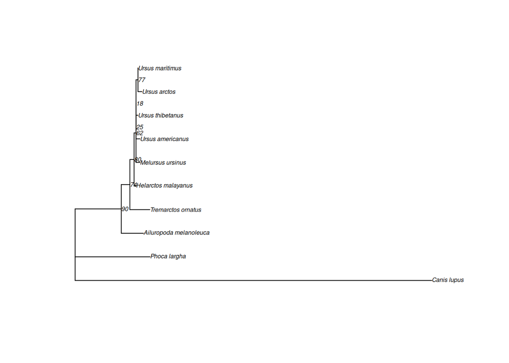

```r
iqtree_est <-read.tree("./bears_irbp.nex.treefile")
plot(iqtree_est, show.node.label=TRUE, cex=0.5)
```

Which relationships have strong support? Which remain uncertain? Remember that a high support value measures consistency under resampling; it does not prove that the model is correct.

```r
params <- extractSubModelLog("./bears_irbp.nex.iqtree")
params
```

```
## $Q
##          a        c        g        t
## a -1.30934  0.15120  1.08000  0.07814
## c  0.08365 -0.80465  0.14710  0.57390
## g  0.61430  0.15120 -0.84364  0.07814
## t  0.08365  1.11000  0.14710 -1.34075
##
## $pi
##      a      c      g      t
## 0.1818 0.3286 0.3197 0.1699
##
## $alpha
## [1] 0.1625
```

Now simulate 100 datasets under the fitted model. We could compare the simulated and empirical datasets in many ways. Here, we will use the built-in summary statistics from `phangorn::glance()`. These statistics are simple and incomplete, but they are useful for demonstrating a simulation-based model check.

```r
summaries <- list()
for(i in 1:100){
  rates <- discrete.gamma(params$alpha, 4)
  data1 <- phangorn::simSeq(iqtree_est, l=320, Q=params$Q, bf=params$pi,  type="DNA", rate=rates[1])
  data2 <- phangorn::simSeq(iqtree_est, l=321, Q=params$Q, bf=params$pi,  type="DNA", rate=rates[2])
  data3 <- phangorn::simSeq(iqtree_est, l=320, Q=params$Q, bf=params$pi,  type="DNA", rate=rates[3])
  data4 <- phangorn::simSeq(iqtree_est, l=320, Q=params$Q, bf=params$pi,  type="DNA", rate=rates[4])
  data <- c(data1, data2, data3, data4)
  summaries[[i]] <- glance(data)
}
summaries <- do.call(rbind, summaries)
summaries
```

```
##     nseq nchar unique_site_pattern parsimony_informative_sites const_sites
## 1     10  1281                  61                          32        1103
## 2     10  1281                  63                          27        1101
## 3     10  1281                  64                          54        1097
## 4     10  1281                  75                          42        1089
## 5     10  1281                  60                          33        1092
## 6     10  1281                  61                          28        1111
## 7     10  1281                  72                          28        1112
## 8     10  1281                  61                          28        1112
## 9     10  1281                  69                          41        1104
## 10    10  1281                  60                          22        1118
## 11    10  1281                  69                          38        1093
## 12    10  1281                  71                          30        1101
## 13    10  1281                  63                          24        1089
## 14    10  1281                  69                          32        1100
```

[output cut: 86 more lines]

```r
irbp <- read.phyDat("./bears_irbp.nex", format="nexus")
irbp_summary <- glance(irbp)
irbp_summary
```

```
##   nseq nchar unique_site_pattern parsimony_informative_sites const_sites
## 1   10  1281                  77                          32        1104
```

Plot each distribution from the simulated datasets and show the observed value from the empirical dataset as a vertical red dotted line. How typical is the observed dataset under the fitted model? A value in the tail suggests that the model does not reproduce that feature of the data well; it does not, by itself, tell us which assumption is responsible.

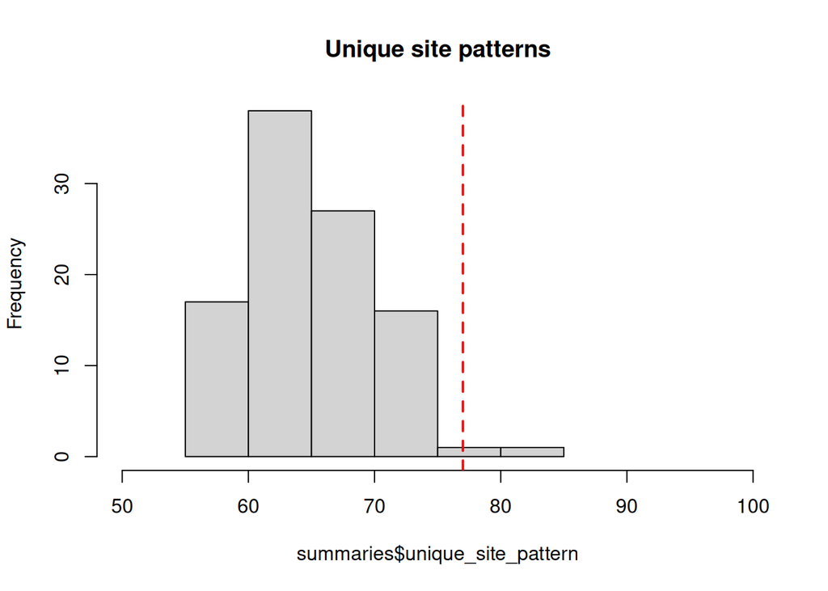

```r
hist(summaries$unique_site_pattern, main="Unique site patterns", xlim=c(50,100))
abline(v=irbp_summary$unique_site_pattern, lty=2, lwd=2, col="red")
```

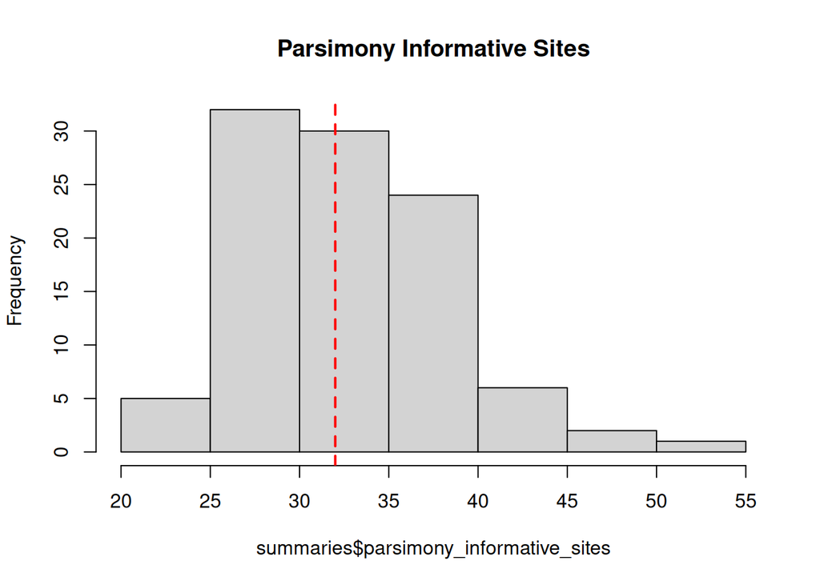

```r
hist(summaries$parsimony_informative_sites, main="Parsimony Informative Sites")
abline(v=irbp_summary$parsimony_informative_sites, lty=2, lwd=2, col="red")
```

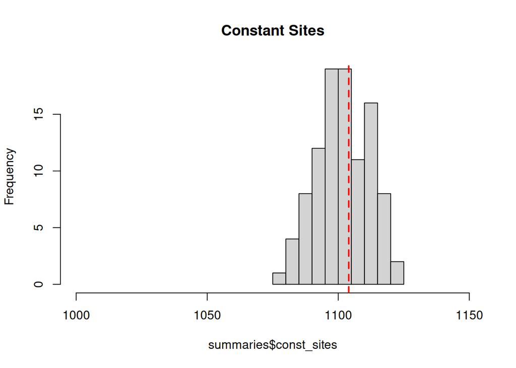

```r
hist(summaries$const_sites, xlim=c(1000, 1150), main="Constant Sites")
abline(v=irbp_summary$const_sites, lty=2, lwd=2, col="red")
```